# Concentration control of the TSOs in the source plates

# Load R packages

```r
library("magrittr")
library("ggplot2")
```

# Load data

Concentrations of the actual TSO solutions in source plates, measured with the NanoDrop instrument for 8-strip tubes (NanoDrop 8000 ?).

Concentration factor was *50* (*A260 × 50 = concentration* in ng/μL).

[[Concentration factor to apply for nanoCAGE TSOs (based on their sequences) = *27.8* (*A260 × 27.8 = concentration* in ng/μL).]]

Original file name `20180419_TSOs_stf.txt`. This file has one sheet containing raw data of old TSOs (first IDT plate ordered) diluted 10x from the original source plate (all TSOs resuspended at 1 mM) and thus at an expected concentration of 100 μM.

```r
plate1 <- gdata::read.xls( "20180419_TSOs_stf2.xlsx"
                        , stringsAsFactors = FALSE)
```

[[Adjust calculated concentrations based on TSOs concentration factor (*27.8*).]]

```r
plate1$plate <- 1
#plate1$Conc..2 <- plate1$A260. * 27.8
conc <- plate1
rm(plate1)
```

```r
conc <- data.frame( Well  = conc$Well
                  , ID    = conc$Sample.ID %>% factor
                  , plate = conc$plate     %>% factor
                  , A260  = conc$A260.
                  , A280  = conc$A280.
                  , obs_conc = conc$Conc..)

conc$Well %<>% factor(levels = levels(conc$Well) %>% gtools::mixedsort())
```

Average replicates.

```r
conc <- aggregate( conc[,c("obs_conc", "A260", "A280")]
                 , list(Well = conc$Well, ID = conc$ID, plate = conc$plate)
                 , mean)
```

Load maker’s information.

```r
idt <- read.csv("TSO_master_plate_PO_8268526.csv")
idt <- idt[,c("Well.Position", "OD260", "nmoles", "µg", "Measured.Molecular.Weight")]
idt$ug.OD <- idt$µg / idt$OD260
idt$Well <- idt$Well.Position %>% sub(pat = "0(.)", rep = "\\1")
conc$conc_corr_Fact <- idt[match(conc$Well, idt$Well), "ug.OD"]
conc$stock_nmoles <- idt[match(conc$Well, idt$Well), "nmoles"]
conc$obs_source_MW <- idt[match(conc$Well, idt$Well), "Measured.Molecular.Weight"]
conc$obs_source_MW <- sub(",", ".", conc$obs_source_MW)
conc$obs_source_MW <- as.numeric(conc$obs_source_MW)
```

Correct concentrations.

```r
conc$corr_obs_conc <- conc$obs_conc / 50 * conc$conc_corr_Fact
```

The expected molarity of TSOs in this measure is 100 μM. The average molecular weight of nanoCAGE TSOs = ~14,000 g/mol, according to IDT plate report. Therefore the expected concentration of TSOs at 100 μM (100 μmol/L) should be: 100 μmol/L * 14000 g/mol = 1.4 g/L = 1400 ng/μL.

```r
conc$exp_molarity <- 100
conc$exp_conc <- conc$exp_molarity * conc$obs_source_MW / 1000
conc$obs_molarity <- (conc$corr_obs_conc*1000) / conc$obs_source_MW
conc <- conc[,c(1:3,5,6,7,8,9,12,4,10,11,13)]
summary(conc)
```

```
##       Well          ID     plate       A260             A280          conc_corr_Fact
##  A1     : 1   1      : 1   1:96   Min.   :-0.108   Min.   :-0.05333   Min.   :30.39
##  A2     : 1   2      : 1          1st Qu.:26.190   1st Qu.:15.14075   1st Qu.:31.17
##  A3     : 1   3      : 1          Median :31.789   Median :17.84550   Median :31.35
##  A4     : 1   4      : 1          Mean   :31.850   Mean   :18.19185   Mean   :31.42
##  A5     : 1   5      : 1          3rd Qu.:36.379   3rd Qu.:20.65233   3rd Qu.:31.66
##  A6     : 1   6      : 1          Max.   :96.918   Max.   :67.15867   Max.   :32.51
##  (Other):90   (Other):90
##   stock_nmoles    obs_source_MW      exp_conc       obs_conc        corr_obs_conc
##  Min.   : 39.00   Min.   :13902   Min.   :1390   Min.   :  -5.394   Min.   :  -3.319
##  1st Qu.: 82.75   1st Qu.:13954   1st Qu.:1395   1st Qu.:1309.500   1st Qu.: 835.789
##  Median : 88.00   Median :13972   Median :1397   Median :1589.167   Median :1003.289
##  Mean   : 86.71   Mean   :13973   Mean   :1397   Mean   :1592.481   Mean   :1000.826
##  3rd Qu.: 94.25   3rd Qu.:13996   3rd Qu.:1400   3rd Qu.:1819.000   3rd Qu.:1144.955
##  Max.   :107.00   Max.   :14053   Max.   :1405   Max.   :4846.000   Max.   :3090.962
##
##   exp_molarity  obs_molarity
##  Min.   :100   Min.   : -0.237
##  1st Qu.:100   1st Qu.: 59.809
##  Median :100   Median : 71.730
##  Mean   :100   Mean   : 71.616
##  3rd Qu.:100   3rd Qu.: 81.922
##  Max.   :100   Max.   :221.414
##
```

```r
out_of_range_down <- subset(conc, conc$obs_molarity < 25)
out_of_range_down
```

```
##    Well ID plate          A260         A280 conc_corr_Fact stock_nmoles obs_source_MW exp_conc
## 12  A12 12     1 -0.1080000000 -0.053333333       30.76923           86       14004.9  1400.49
## 53   E5 53     1  0.0010000000  0.016666667       31.70833           55       13947.7  1394.77
## 54   E6 54     1 -0.0006666667  0.009000000       32.05000           46       14006.4  1400.64
## 56   E8 56     1  0.0003333333  0.013000000       30.38889           39       14004.5  1400.45
## 84  G12 84     1 -0.0110000000 -0.008666667       31.08108           82       13996.7  1399.67
## 93   H9 93     1  0.0090000000 -0.009666667       31.13158           85       13955.1  1395.51
## 94  H10 94     1  0.4066666667  0.256000000       31.27778           81       13971.8  1397.18
## 95  H11 95     1 -0.0003333333 -0.006000000       31.71795           89       13962.9  1396.29
## 96  H12 96     1 -0.0063333333 -0.014333333       32.15789           88       13922.4  1392.24
##        obs_conc corr_obs_conc exp_molarity  obs_molarity
## 12 -5.394000000 -3.3193846154          100 -2.370159e-01
## 53  0.050871667  0.0322611153          100  2.313006e-03
## 54 -0.033663333 -0.0215781967          100 -1.540595e-03
## 56  0.026026667  0.0158184296          100  1.129525e-03
## 84 -0.541333333 -0.3365045045          100 -2.404170e-02
## 93  0.449100000  0.2796238421          100  2.003739e-02
## 94 20.336666667 12.7217148148          100  9.105280e-01
## 95 -0.001133333 -0.0007189402          100 -5.148932e-05
## 96 -0.321470000 -0.2067559684          100 -1.485060e-02
```

```r
nrow(out_of_range_down)
```

```
## [1] 9
```

```r
out_of_range_down$Well
```

```
## [1] A12 E5  E6  E8  G12 H9  H10 H11 H12
## 96 Levels: A1 A2 A3 A4 A5 A6 A7 A8 A9 A10 A11 A12 B1 B2 B3 B4 B5 B6 B7 B8 B9 B10 B11 B12 C1 ... H12
```

```r
out_of_range_up <- subset(conc, conc$obs_molarity > 175)
out_of_range_up
```

```
##    Well ID plate     A260     A280 conc_corr_Fact stock_nmoles obs_source_MW exp_conc obs_conc
## 72  F12 72     1 91.10700 54.95200       31.91892           84       13987.9  1398.79 4555.333
## 90   H6 90     1 91.92967 55.43900       31.25641           87       13998.5  1399.85 4596.667
## 91   H7 91     1 96.91833 67.15867       31.89189           85       13960.1  1396.01 4846.000
## 92   H8 92     1 86.55067 53.21567       31.31818           99       13965.8  1396.58 4327.667
##    corr_obs_conc exp_molarity obs_molarity
## 72      2908.026          100     207.8958
## 90      2873.506          100     205.2724
## 91      3090.962          100     221.4140
## 92      2710.693          100     194.0951
```

```r
nrow(out_of_range_up)
```

```
## [1] 4
```

```r
out_of_range_up$Well
```

```
## [1] F12 H6  H7  H8
## 96 Levels: A1 A2 A3 A4 A5 A6 A7 A8 A9 A10 A11 A12 B1 B2 B3 B4 B5 B6 B7 B8 B9 B10 B11 B12 C1 ... H12
```

```r
conc$delta_molarity <- conc$exp_molarity - conc$obs_molarity
in_range <- subset(conc, abs(conc$delta_molarity) < 25)
in_range
```

```
##    Well ID plate     A260     A280 conc_corr_Fact stock_nmoles obs_source_MW exp_conc obs_conc
## 1    A1  1     1 42.55033 23.27133       31.19512           92       13963.5  1396.35 2127.667
## 2    A2  2     1 37.17533 21.52067       31.34884           97       13956.1  1395.61 1859.000
## 3    A3  3     1 40.17600 23.13067       31.54762           95       13916.9  1391.69 2008.667
## 4    A4  4     1 36.45467 19.51700       30.72973           81       13991.2  1399.12 1823.000
## 7    A7  7     1 34.43767 18.72133       30.72973           82       13939.8  1393.98 1721.667
## 10  A10 10     1 40.16833 22.43400       31.18605           96       14004.9  1400.49 2008.333
## 16   B4 16     1 39.74333 21.51067       31.12821           87       13996.0  1399.60 1987.000
## 18   B6 18     1 35.22200 19.25167       31.33333          101       14052.9  1405.29 1761.333
## 19   B7 19     1 33.87067 18.97433       31.14634           92       13979.4  1397.94 1693.667
## 21   B9 21     1 37.30167 20.48433       31.06977           96       13989.9  1398.99 1865.333
## 23  B11 23     1 33.94967 19.04667       31.02500           89       13955.0  1395.50 1697.667
## 27   C3 27     1 38.38933 22.03100       31.00000           84       13979.3  1397.93 1919.333
## 37   D1 37     1 36.17967 20.97467       31.63889           82       13989.4  1398.94 1809.000
## 38   D2 38     1 38.86000 21.39500       31.64706           77       13996.2  1399.62 1943.000
```

[output cut: 51 more lines]

```r
nrow(in_range)
```

```
## [1] 32
```

```r
in_range$Well
```

```
##  [1] A1  A2  A3  A4  A7  A10 B4  B6  B7  B9  B11 C3  D1  D2  D3  D4  D6  D9  D10 D11 D12 E1  E9  E11
## [25] E12 F3  G1  G4  H2  H3  H4  H5
## 96 Levels: A1 A2 A3 A4 A5 A6 A7 A8 A9 A10 A11 A12 B1 B2 B3 B4 B5 B6 B7 B8 B9 B10 B11 B12 C1 ... H12
```

# Histograms

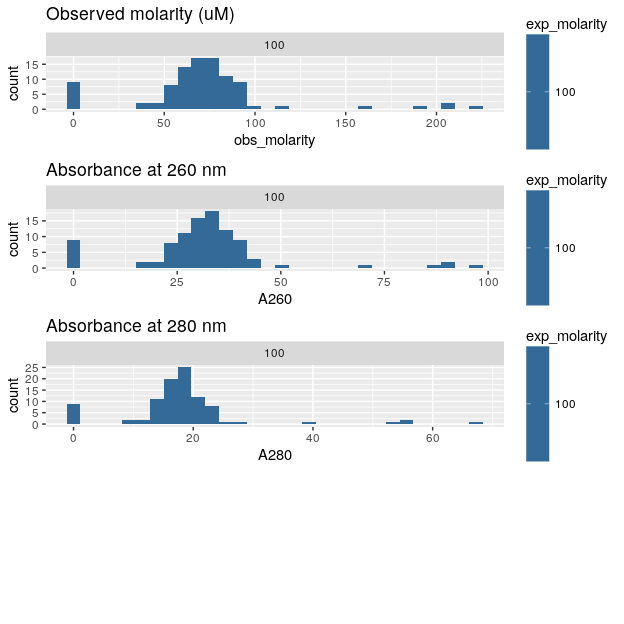

```r
#hist_obs_concentration <- ggplot(conc, aes(corr_obs_conc,  fill = exp_conc)) + geom_histogram() +
#  facet_wrap(~exp_conc, nrow = 1) + ggtitle("Observed concentrations (ng/μL)")
hist_obs_molarity  <- ggplot(conc, aes(obs_molarity,  fill = exp_molarity)) + geom_histogram() +
  facet_wrap(~exp_molarity, nrow = 1) + ggtitle("Observed molarity (uM)")
hist_a260 <- ggplot(conc, aes(A260, fill = exp_molarity)) + geom_histogram() +
  facet_wrap(~exp_molarity, nrow = 1) + ggtitle("Absorbance at 260 nm")
hist_a280 <- ggplot(conc, aes(A280, fill = exp_molarity)) + geom_histogram() +
  facet_wrap(~exp_molarity, nrow = 1) + ggtitle("Absorbance at 280 nm")

ggpubr::ggarrange( ncol = 1, nrow = 4, hist_obs_molarity, hist_a260, hist_a280)
```

# Absorbances

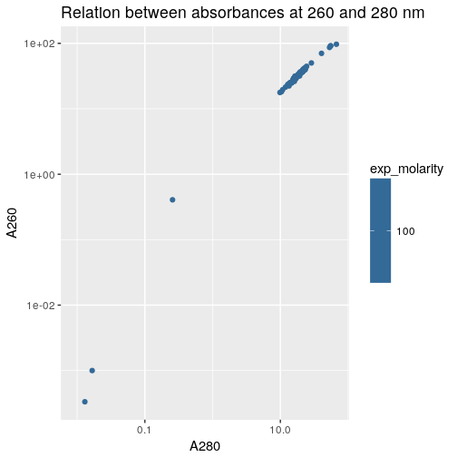

```r
ggplot(conc, aes(A280, A260, colour = exp_molarity)) + geom_point() +
    scale_x_log10() + scale_y_log10() +
  ggtitle("Relation between absorbances at 260 and 280 nm")
```

# Concentrations

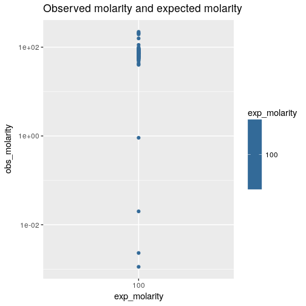

```r
ggplot(conc, aes(exp_molarity,  obs_molarity, colour = exp_molarity))  + geom_point() +
  scale_x_log10() + scale_y_log10() +
  ggtitle("Observed molarity and expected molarity")
```

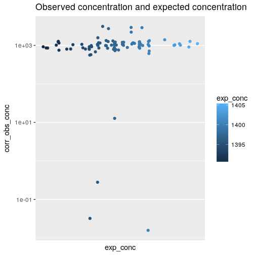

```r
ggplot(conc, aes(exp_conc,  corr_obs_conc, colour = exp_conc))  + geom_point() +
  scale_x_log10() + scale_y_log10() +
  ggtitle("Observed concentration and expected concentration")
```

# Dilution factor

```r
conc$source_obs_molarity <- conc$obs_molarity * 10
conc$dilution_factor_for_100uM <- conc$source_obs_molarity / 100
conc$TSO_vol_for_100uM <- 20 / conc$dilution_factor_for_100uM
conc$H20_vol_for_100uM <- 20 - conc$TSO_vol_for_100uM
```

```r
do_not_use <- subset(conc, conc$dilution_factor_for_100uM < 2)
do_not_use
```

```
##    Well ID plate          A260         A280 conc_corr_Fact stock_nmoles obs_source_MW exp_conc
## 12  A12 12     1 -0.1080000000 -0.053333333       30.76923           86       14004.9  1400.49
## 53   E5 53     1  0.0010000000  0.016666667       31.70833           55       13947.7  1394.77
## 54   E6 54     1 -0.0006666667  0.009000000       32.05000           46       14006.4  1400.64
## 56   E8 56     1  0.0003333333  0.013000000       30.38889           39       14004.5  1400.45
## 84  G12 84     1 -0.0110000000 -0.008666667       31.08108           82       13996.7  1399.67
## 93   H9 93     1  0.0090000000 -0.009666667       31.13158           85       13955.1  1395.51
## 94  H10 94     1  0.4066666667  0.256000000       31.27778           81       13971.8  1397.18
## 95  H11 95     1 -0.0003333333 -0.006000000       31.71795           89       13962.9  1396.29
## 96  H12 96     1 -0.0063333333 -0.014333333       32.15789           88       13922.4  1392.24
##        obs_conc corr_obs_conc exp_molarity  obs_molarity delta_molarity source_obs_molarity
## 12 -5.394000000 -3.3193846154          100 -2.370159e-01      100.23702       -2.3701594552
## 53  0.050871667  0.0322611153          100  2.313006e-03       99.99769        0.0231300611
## 54 -0.033663333 -0.0215781967          100 -1.540595e-03      100.00154       -0.0154059549
## 56  0.026026667  0.0158184296          100  1.129525e-03       99.99887        0.0112952477
## 84 -0.541333333 -0.3365045045          100 -2.404170e-02      100.02404       -0.2404170301
## 93  0.449100000  0.2796238421          100  2.003739e-02       99.97996        0.2003739437
## 94 20.336666667 12.7217148148          100  9.105280e-01       99.08947        9.1052797884
## 95 -0.001133333 -0.0007189402          100 -5.148932e-05      100.00005       -0.0005148932
## 96 -0.321470000 -0.2067559684          100 -1.485060e-02      100.01485       -0.1485059820
##    dilution_factor_for_100uM TSO_vol_for_100uM H20_vol_for_100uM
## 12             -2.370159e-02         -843.8251          863.8251
## 53              2.313006e-04        86467.5625       -86447.5625
## 54             -1.540595e-04      -129819.9309       129839.9309
## 56              1.129525e-04       177065.6169      -177045.6169
## 84             -2.404170e-03        -8318.8782         8338.8782
## 93              2.003739e-03         9981.3377        -9961.3377
## 94              9.105280e-02          219.6528         -199.6528
## 95             -5.148932e-06     -3884300.9653      3884320.9653
## 96             -1.485060e-03       -13467.4710        13487.4710
```

```r
nrow(do_not_use)
```

```
## [1] 9
```

```r
do_not_use$Well
```

```
## [1] A12 E5  E6  E8  G12 H9  H10 H11 H12
## 96 Levels: A1 A2 A3 A4 A5 A6 A7 A8 A9 A10 A11 A12 B1 B2 B3 B4 B5 B6 B7 B8 B9 B10 B11 B12 C1 ... H12
```

Create dilution table.

```r
dilution_table <- conc[, c("Well", "dilution_factor_for_100uM", "TSO_vol_for_100uM", "H20_vol_for_100uM")]
```

Print tables.

```r
write.table(conc, "old_TSOs_check2.txt", row.names = FALSE, col.names = TRUE, quote = FALSE, sep = "\t")
write.table(do_not_use, "do_not_use_TSOs_.txt", row.names = FALSE, col.names = TRUE, quote = FALSE, sep = "\t")
write.table(dilution_table, "dilution_table.txt", row.names = FALSE, col.names = TRUE, quote = FALSE, sep = "\t")
```